# The Movie Database: 10-Year Quarterly Analysis

- Introduction
- Data Wrangling
- Exploratory Data Analysis
- Conclusions

## Introduction

> In this project, a subset of data associated with The Movie Dataset found on [Kaggle](https://www.kaggle.com/datasets/rounakbanik/the-movies-dataset), will be analyzed. The past 10 years of data will be extracted to find which quarter of the year results in the least revenue on average and how the number of movies released affected the revenue.

```python
import pandas as pd, numpy as np, matplotlib.pyplot as plt, seaborn as sb
%matplotlib inline
```

### Custom Functions

**add_quarter**: A function for creating a quarter column. The month will be extracted from the `release_date`, divided into yearly quarters, and appended to the selected dataframe in a `quarter` column.

```python
def add_quarter(dfname):
    # Get release month
    month = dfname['release_date'].dt.month

    # Bin edges will used to cut the data into quarters
    bin_edges = [0, 3, 6, 9, 12]

    # Bin names will be used to label the quarters
    bin_names = ['Q1', 'Q2', 'Q3','Q4']

    # Create column
    dfname['quarter'] = pd.cut(month, bin_edges, labels=bin_names)

    pass
```

**qtr_rev_means**: A function for determining the average revenue by quarter. It accepts the dataframe name (`dfname`) as the parameter, and if NaN is present, value is filled with 0.

```python
def qtr_rev_means(dfname):
    means = dfname.groupby(['quarter']).revenue.mean()
    result = means.fillna(0)
    return result
```

**dtype_convert**: A function for simple datatype conversions that operates by collecting the dataframe name (`dfname`), column name (`column`), and desired datatype (`datatype`).

*Note*: Not to be used for more complex conversions such as datetime.

```python
def dtype_convert(dfname, column, datatype):
    dfname['' + column + ''] = dfname['' + column + ''].astype(datatype)
    return dfname.dtypes
```

## Data Wrangling

### General Properties

```python
# Loads The Movie Database dataset
df = pd.read_csv('tmdb-movies.csv')
df.head()
```

|  | id | imdb_id | popularity | budget | revenue | original_title | cast | homepage | director | tagline | ... | overview | runtime | genres | production_companies | release_date | vote_count | vote_average | release_year | budget_adj | revenue_adj |
| --- | --- | --- | --- | --- | --- | --- | --- | --- | --- | --- | --- | --- | --- | --- | --- | --- | --- | --- | --- | --- | --- |
| 0 | 135397 | tt0369610 | 32.985763 | 150000000 | 1513528810 | Jurassic World | Chris Pratt\|Bryce Dallas Howard\|Irrfan Khan\|Vi... | http://www.jurassicworld.com/ | Colin Trevorrow | The park is open. | ... | Twenty-two years after the events of Jurassic ... | 124 | Action\|Adventure\|Science Fiction\|Thriller | Universal Studios\|Amblin Entertainment\|Legenda... | 6/9/15 | 5562 | 6.5 | 2015 | 1.379999e+08 | 1.392446e+09 |
| 1 | 76341 | tt1392190 | 28.419936 | 150000000 | 378436354 | Mad Max: Fury Road | Tom Hardy\|Charlize Theron\|Hugh Keays-Byrne\|Nic... | http://www.madmaxmovie.com/ | George Miller | What a Lovely Day. | ... | An apocalyptic story set in the furthest reach... | 120 | Action\|Adventure\|Science Fiction\|Thriller | Village Roadshow Pictures\|Kennedy Miller Produ... | 5/13/15 | 6185 | 7.1 | 2015 | 1.379999e+08 | 3.481613e+08 |
| 2 | 262500 | tt2908446 | 13.112507 | 110000000 | 295238201 | Insurgent | Shailene Woodley\|Theo James\|Kate Winslet\|Ansel... | http://www.thedivergentseries.movie/#insurgent | Robert Schwentke | One Choice Can Destroy You | ... | Beatrice Prior must confront her inner demons ... | 119 | Adventure\|Science Fiction\|Thriller | Summit Entertainment\|Mandeville Films\|Red Wago... | 3/18/15 | 2480 | 6.3 | 2015 | 1.012000e+08 | 2.716190e+08 |
| 3 | 140607 | tt2488496 | 11.173104 | 200000000 | 2068178225 | Star Wars: The Force Awakens | Harrison Ford\|Mark Hamill\|Carrie Fisher\|Adam D... | http://www.starwars.com/films/star-wars-episod... | J.J. Abrams | Every generation has a story. | ... | Thirty years after defeating the Galactic Empi... | 136 | Action\|Adventure\|Science Fiction\|Fantasy | Lucasfilm\|Truenorth Productions\|Bad Robot | 12/15/15 | 5292 | 7.5 | 2015 | 1.839999e+08 | 1.902723e+09 |
| 4 | 168259 | tt2820852 | 9.335014 | 190000000 | 1506249360 | Furious 7 | Vin Diesel\|Paul Walker\|Jason Statham\|Michelle ... | http://www.furious7.com/ | James Wan | Vengeance Hits Home | ... | Deckard Shaw seeks revenge against Dominic Tor... | 137 | Action\|Crime\|Thriller | Universal Pictures\|Original Film\|Media Rights ... | 4/1/15 | 2947 | 7.3 | 2015 | 1.747999e+08 | 1.385749e+09 |

5 rows × 21 columns

```python
# Get information
df.info()
```

```
<class 'pandas.core.frame.DataFrame'>
RangeIndex: 10866 entries, 0 to 10865
Data columns (total 21 columns):
 #   Column                Non-Null Count  Dtype
---  ------                --------------  -----
 0   id                    10866 non-null  int64
 1   imdb_id               10856 non-null  object
 2   popularity            10866 non-null  float64
 3   budget                10866 non-null  int64
 4   revenue               10866 non-null  int64
 5   original_title        10866 non-null  object
 6   cast                  10790 non-null  object
 7   homepage              2936 non-null   object
 8   director              10822 non-null  object
 9   tagline               8042 non-null   object
 10  keywords              9373 non-null   object
 11  overview              10862 non-null  object
 12  runtime               10866 non-null  int64
 13  genres                10843 non-null  object
 14  production_companies  9836 non-null   object
 15  release_date          10866 non-null  object
 16  vote_count            10866 non-null  int64
 17  vote_average          10866 non-null  float64
 18  release_year          10866 non-null  int64
 19  budget_adj            10866 non-null  float64
 20  revenue_adj           10866 non-null  float64
dtypes: float64(4), int64(6), object(11)
memory usage: 1.7+ MB
```

```python
# Get statistics
df.describe()
```

|  | id | popularity | budget | revenue | runtime | vote_count | vote_average | release_year | budget_adj | revenue_adj |
| --- | --- | --- | --- | --- | --- | --- | --- | --- | --- | --- |
| count | 10866.000000 | 10866.000000 | 1.086600e+04 | 1.086600e+04 | 10866.000000 | 10866.000000 | 10866.000000 | 10866.000000 | 1.086600e+04 | 1.086600e+04 |
| mean | 66064.177434 | 0.646441 | 1.462570e+07 | 3.982332e+07 | 102.070863 | 217.389748 | 5.974922 | 2001.322658 | 1.755104e+07 | 5.136436e+07 |
| std | 92130.136561 | 1.000185 | 3.091321e+07 | 1.170035e+08 | 31.381405 | 575.619058 | 0.935142 | 12.812941 | 3.430616e+07 | 1.446325e+08 |
| min | 5.000000 | 0.000065 | 0.000000e+00 | 0.000000e+00 | 0.000000 | 10.000000 | 1.500000 | 1960.000000 | 0.000000e+00 | 0.000000e+00 |
| 25% | 10596.250000 | 0.207583 | 0.000000e+00 | 0.000000e+00 | 90.000000 | 17.000000 | 5.400000 | 1995.000000 | 0.000000e+00 | 0.000000e+00 |
| 50% | 20669.000000 | 0.383856 | 0.000000e+00 | 0.000000e+00 | 99.000000 | 38.000000 | 6.000000 | 2006.000000 | 0.000000e+00 | 0.000000e+00 |
| 75% | 75610.000000 | 0.713817 | 1.500000e+07 | 2.400000e+07 | 111.000000 | 145.750000 | 6.600000 | 2011.000000 | 2.085325e+07 | 3.369710e+07 |
| max | 417859.000000 | 32.985763 | 4.250000e+08 | 2.781506e+09 | 900.000000 | 9767.000000 | 9.200000 | 2015.000000 | 4.250000e+08 | 2.827124e+09 |

## Data Cleaning

> In this section, a subset of data that captures the previous 10-years will be created and only include relevant columns (listed below). Missing/null and duplicate rows will be investigated and resolved as well as any incorrect data types.

### Create the New Dataframe

Capture the previous 10 years of data that only includes known essential columns

```python
# Create new data frame
ten_df = df[['id', 'popularity', 'revenue', 'original_title',
       'genres', 'release_date', 'release_year']].query('release_year >= 2006')
ten_df.head()
```

|  | id | popularity | revenue | original_title | genres | release_date | release_year |
| --- | --- | --- | --- | --- | --- | --- | --- |
| 0 | 135397 | 32.985763 | 1513528810 | Jurassic World | Action\|Adventure\|Science Fiction\|Thriller | 6/9/15 | 2015 |
| 1 | 76341 | 28.419936 | 378436354 | Mad Max: Fury Road | Action\|Adventure\|Science Fiction\|Thriller | 5/13/15 | 2015 |
| 2 | 262500 | 13.112507 | 295238201 | Insurgent | Adventure\|Science Fiction\|Thriller | 3/18/15 | 2015 |
| 3 | 140607 | 11.173104 | 2068178225 | Star Wars: The Force Awakens | Action\|Adventure\|Science Fiction\|Fantasy | 12/15/15 | 2015 |
| 4 | 168259 | 9.335014 | 1506249360 | Furious 7 | Action\|Crime\|Thriller | 4/1/15 | 2015 |

```python
# Confirm release_year range
ten_df['release_year'].describe()
```

```
count    5481.000000
mean     2010.942711
std         2.829202
min      2006.000000
25%      2009.000000
50%      2011.000000
75%      2013.000000
max      2015.000000
Name: release_year, dtype: float64
```

```python
# View updated info
ten_df.info()
```

```
<class 'pandas.core.frame.DataFrame'>
Index: 5481 entries, 0 to 7824
Data columns (total 7 columns):
 #   Column          Non-Null Count  Dtype
---  ------          --------------  -----
 0   id              5481 non-null   int64
 1   popularity      5481 non-null   float64
 2   revenue         5481 non-null   int64
 3   original_title  5481 non-null   object
 4   genres          5466 non-null   object
 5   release_date    5481 non-null   object
 6   release_year    5481 non-null   int64
dtypes: float64(1), int64(3), object(3)
memory usage: 342.6+ KB
```

### Duplicates

Find and remove duplicate rows

```python
# Check for duplicate movies
ten_df.duplicated('id').sum()
```

```
1
```

```python
# View duplicated data
ten_df[ten_df['id'].duplicated()]
```

|  | id | popularity | revenue | original_title | genres | release_date | release_year |
| --- | --- | --- | --- | --- | --- | --- | --- |
| 2090 | 42194 | 0.59643 | 967000 | TEKKEN | Crime\|Drama\|Action\|Thriller\|Science Fiction | 3/20/10 | 2010 |

```python
# Drop duplicate movie
ten_df.drop_duplicates(inplace=True)
ten_df.duplicated('id').sum()
```

```
0
```

### Missing/Null Data

The info of the 10-year dataframe shows that there are missing genre field values. These will need to be resolved.

```python
# Check for rows with missing genre
ten_df[ten_df['genres'].isnull()]
```

|  | id | popularity | revenue | original_title | genres | release_date | release_year |
| --- | --- | --- | --- | --- | --- | --- | --- |
| 424 | 363869 | 0.244648 | 0 | Belli di papÃ | NaN | 10/29/15 | 2015 |
| 620 | 361043 | 0.129696 | 0 | All Hallows' Eve 2 | NaN | 10/6/15 | 2015 |
| 997 | 287663 | 0.330431 | 0 | Star Wars Rebels: Spark of Rebellion | NaN | 10/3/14 | 2014 |
| 1712 | 21634 | 0.302095 | 0 | Prayers for Bobby | NaN | 2/27/09 | 2009 |
| 1897 | 40534 | 0.020701 | 0 | Jonas Brothers: The Concert Experience | NaN | 2/27/09 | 2009 |
| 2370 | 127717 | 0.081892 | 0 | Freshman Father | NaN | 6/5/10 | 2010 |
| 2376 | 315620 | 0.068411 | 0 | Doctor Who: A Christmas Carol | NaN | 12/25/10 | 2010 |
| 3279 | 54330 | 0.145331 | 0 | ì•„ê¸°ì™€ ë‚˜ | NaN | 8/13/08 | 2008 |
| 4547 | 123024 | 0.520520 | 0 | London 2012 Olympic Opening Ceremony: Isles of... | NaN | 7/27/12 | 2012 |
| 4732 | 139463 | 0.235911 | 0 | The Scapegoat | NaN | 9/9/12 | 2012 |
| 4797 | 369145 | 0.167501 | 0 | Doctor Who: The Snowmen | NaN | 12/25/12 | 2012 |
| 4890 | 126909 | 0.083202 | 0 | Cousin Ben Troop Screening | NaN | 1/1/12 | 2012 |
| 5830 | 282848 | 0.248944 | 0 | Doctor Who: The Time of the Doctor | NaN | 12/25/13 | 2013 |
| 5934 | 200204 | 0.067433 | 0 | Prada: Candy | NaN | 3/25/13 | 2013 |
| 6043 | 190940 | 0.039080 | 0 | Bombay Talkies | NaN | 5/3/13 | 2013 |

> Since these are objects and a relatively low number are missing, these rows can be dropped.

```python
# Drop rows with missing genres
ten_df.dropna(inplace=True)
ten_df.info()
```

```
<class 'pandas.core.frame.DataFrame'>
Index: 5465 entries, 0 to 7824
Data columns (total 7 columns):
 #   Column          Non-Null Count  Dtype
---  ------          --------------  -----
 0   id              5465 non-null   int64
 1   popularity      5465 non-null   float64
 2   revenue         5465 non-null   int64
 3   original_title  5465 non-null   object
 4   genres          5465 non-null   object
 5   release_date    5465 non-null   object
 6   release_year    5465 non-null   int64
dtypes: float64(1), int64(3), object(3)
memory usage: 341.6+ KB
```

```python
# Investigate revenue data
ten_df.query('revenue == 0')
```

|  | id | popularity | revenue | original_title | genres | release_date | release_year |
| --- | --- | --- | --- | --- | --- | --- | --- |
| 48 | 265208 | 2.932340 | 0 | Wild Card | Thriller\|Crime\|Drama | 1/14/15 | 2015 |
| 67 | 334074 | 2.331636 | 0 | Survivor | Crime\|Thriller\|Action | 5/21/15 | 2015 |
| 74 | 347096 | 2.165433 | 0 | Mythica: The Darkspore | Action\|Adventure\|Fantasy | 6/24/15 | 2015 |
| 75 | 308369 | 2.141506 | 0 | Me and Earl and the Dying Girl | Comedy\|Drama | 6/12/15 | 2015 |
| 92 | 370687 | 1.876037 | 0 | Mythica: The Necromancer | Fantasy\|Action\|Adventure | 12/19/15 | 2015 |
| ... | ... | ... | ... | ... | ... | ... | ... |
| 7818 | 46169 | 0.019669 | 0 | Twitches Too | Drama\|Family\|Fantasy\|TV Movie | 10/12/07 | 2007 |
| 7820 | 21623 | 0.017396 | 0 | Beneath | Horror\|Mystery\|Thriller | 7/8/07 | 2007 |
| 7821 | 39561 | 0.013017 | 0 | Testosteron | Comedy | 3/2/07 | 2007 |
| 7822 | 36443 | 0.010471 | 0 | The Union: The Business Behind Getting High | Comedy\|Documentary | 5/8/07 | 2007 |
| 7823 | 19934 | 0.009512 | 0 | Ce soir je dors chez toi | Comedy | 11/21/07 | 2007 |

3296 rows × 7 columns

```python
# Set revenue values of 0 to the mean revenue
rev_mean = ten_df['revenue'].mean().astype(int)
ten_df['revenue'] = ten_df['revenue'].replace(0, rev_mean)
```

```python
# Validate change
ten_df.query('revenue == 0').count()
```

```
id                0
popularity        0
revenue           0
original_title    0
genres            0
release_date      0
release_year      0
dtype: int64
```

> The release data is shown as having a datatype of object (string). It will need to be corrected by converting it to datetime instead.

```python
# Convert release_date from string to datetime datatype
ten_df['release_date'] = pd.to_datetime(ten_df['release_date'], format='%m/%d/%y')
ten_df.info()
```

```
<class 'pandas.core.frame.DataFrame'>
Index: 5465 entries, 0 to 7824
Data columns (total 7 columns):
 #   Column          Non-Null Count  Dtype
---  ------          --------------  -----
 0   id              5465 non-null   int64
 1   popularity      5465 non-null   float64
 2   revenue         5465 non-null   int64
 3   original_title  5465 non-null   object
 4   genres          5465 non-null   object
 5   release_date    5465 non-null   datetime64[ns]
 6   release_year    5465 non-null   int64
dtypes: datetime64[ns](1), float64(1), int64(3), object(2)
memory usage: 341.6+ KB
```

## Exploratory Data Analysis

> First, the columns of the dataset will be examined to extract any useful information that can be derived from the individual attributes of the dataset; separated by **qualitative** and **quantitative** data.

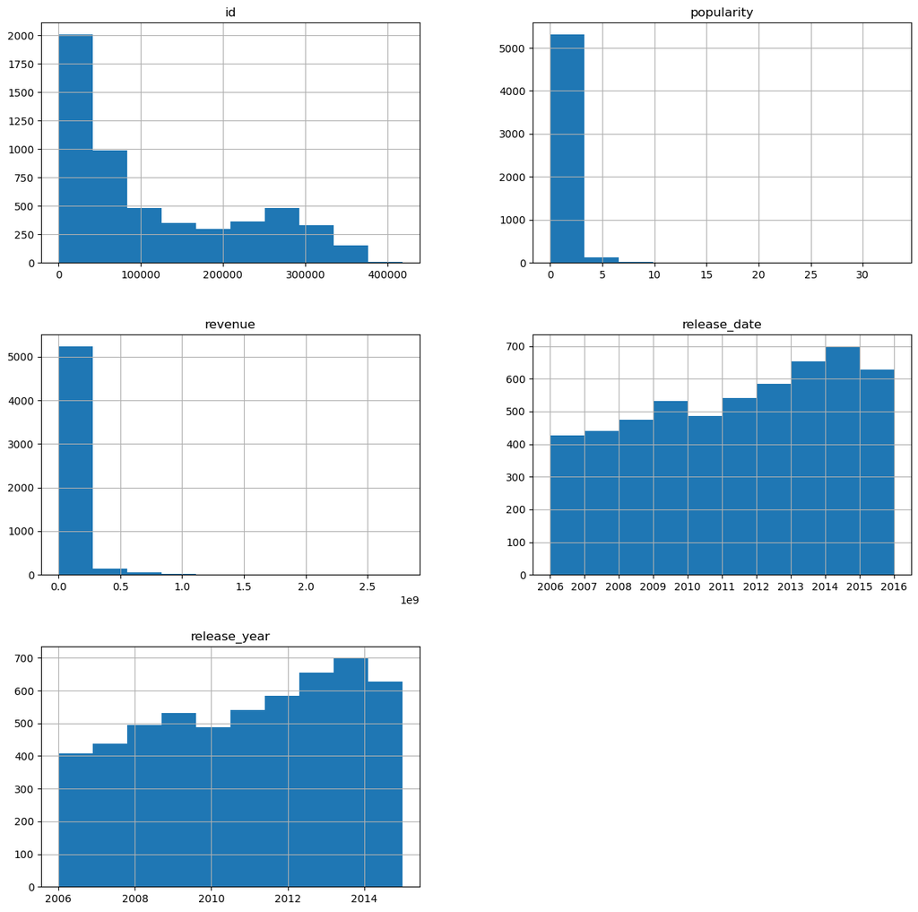

```python
#Plot histograms: Qualitative data
ten_df.hist(figsize = (15,15));
```

> One observation from the historic data is that the number of movies released increased over time. This information is shown by the gradual count increase on both the `release_date` and `release_year` charts.

```python
# Separate the 'genres' column and regroup by individual genre
genre_list = ten_df['genres'].str.cat(sep='|')
genre_split = pd.Series(genre_list.split('|'))
genre_split.value_counts()
```

```
Drama              2304
Comedy             1712
Thriller           1488
Action             1060
Horror              893
Romance             756
Adventure           624
Crime               571
Science Fiction     558
Family              530
Documentary         411
Fantasy             405
Animation           405
Mystery             363
Music               204
History             144
War                 108
TV Movie            103
Foreign              95
Western              36
Name: count, dtype: int64
```

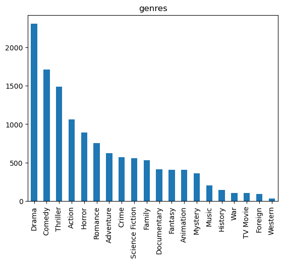

```python
# Plot bar chart: Quantitative data
genre_split.value_counts().plot(title = 'genres', kind='bar');
```

> The majority of movies were categorized as a drama, comedy, and/or thriller, respectively, during for this decade of data. Relatively, there were very few categorized as western, TV movies, or foreign.

> Now that the individual features have been explored, the relationship between the features can be inspected. This section will focus on how `revenue' relates to some of the other features.

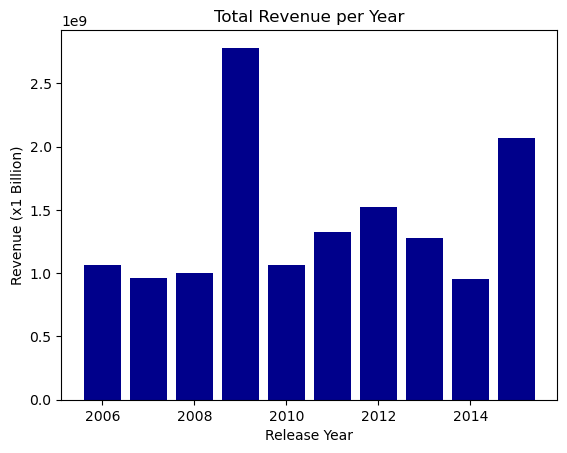

```python
# Plot bar chart: "Revenue by Release Year"
plt.bar(ten_df['release_year'], ten_df['revenue'], color = 'darkblue')
plt.xlabel('Release Year')
plt.ylabel('Revenue (x1 Billion)')
plt.title('Total Revenue per Year')
plt.show()
```

> The above chart shows 2009 and 2015 standing out with significantly higher revenues and 2012 appearing to be above the normal range too, while the remaining years have revenues that are realtively consistent. The observations suggests that these 2009 and 2015 years experienced financial success possibly due to well received film(s) in some capacity.

> To see if there is any correlation, the revenue in comparison to popularity will be examined.

```
correlation :  PearsonRResult(statistic=0.6344262650111495, pvalue=0.0)
```

```
(-10000000.0, 1500000000.0)
```

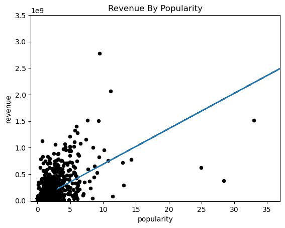

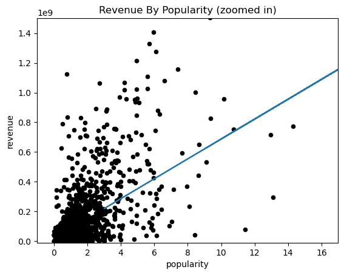

```python
#Plot Scatter: "Revenue by Popularity"
import statsmodels.api as sm
import scipy
model = sm.OLS(ten_df.revenue, sm.add_constant(ten_df.popularity))
p = model.fit().params
x= ten_df.revenue
ax = ten_df.plot(x='popularity', y='revenue', title = 'Revenue By Popularity', kind='scatter', color = 'black');
ax.plot(x, p.const + p.popularity* x)
ax.set_xlim([-1, 37])
ax.set_ylim([-10000000, 3500000000])
print("correlation : ", scipy.stats.pearsonr(ten_df.popularity, ten_df.revenue)),


model = sm.OLS(ten_df.revenue, sm.add_constant(ten_df.popularity))
p = model.fit().params
x= ten_df.revenue
ax = ten_df.plot(x='popularity', y='revenue', title = 'Revenue By Popularity (zoomed in)', kind='scatter', color = 'black');
ax.plot(x, p.const + p.popularity* x)
ax.set_xlim([-1, 17])
ax.set_ylim([-10000000, 1500000000])
```

> The correlation is positive between revenue and popularity. There are a few outliers shown in the first scatter plot for both features. The use of queries will help determine if there is any relation to the previous bar chart.

```python
# View population outliers
ten_df.query('popularity > 20')
```

|  | id | popularity | revenue | original_title | genres | release_date | release_year |
| --- | --- | --- | --- | --- | --- | --- | --- |
| 0 | 135397 | 32.985763 | 1513528810 | Jurassic World | Action\|Adventure\|Science Fiction\|Thriller | 2015-06-09 | 2015 |
| 1 | 76341 | 28.419936 | 378436354 | Mad Max: Fury Road | Action\|Adventure\|Science Fiction\|Thriller | 2015-05-13 | 2015 |
| 629 | 157336 | 24.949134 | 621752480 | Interstellar | Adventure\|Drama\|Science Fiction | 2014-11-05 | 2014 |

```python
# View revenue outliers
ten_df.query('revenue > 1.5e9')
```

|  | id | popularity | revenue | original_title | genres | release_date | release_year |
| --- | --- | --- | --- | --- | --- | --- | --- |
| 0 | 135397 | 32.985763 | 1513528810 | Jurassic World | Action\|Adventure\|Science Fiction\|Thriller | 2015-06-09 | 2015 |
| 3 | 140607 | 11.173104 | 2068178225 | Star Wars: The Force Awakens | Action\|Adventure\|Science Fiction\|Fantasy | 2015-12-15 | 2015 |
| 4 | 168259 | 9.335014 | 1506249360 | Furious 7 | Action\|Crime\|Thriller | 2015-04-01 | 2015 |
| 1386 | 19995 | 9.432768 | 2781505847 | Avatar | Action\|Adventure\|Fantasy\|Science Fiction | 2009-12-10 | 2009 |
| 4361 | 24428 | 7.637767 | 1519557910 | The Avengers | Science Fiction\|Action\|Adventure | 2012-04-25 | 2012 |

> As shown, some of the extremely popular movies were released in 2015. This also is observed with the movies that have extremely high revenues. However, it is still not definitive if the revenue for each year is effected by the highly popular movies.

> An additional step can be taken to see how all three, release year, title, and revenue, relate.

```python
# View movies with the highest revenue by year
max_rev_ind = ten_df.groupby('release_year')['revenue'].idxmax()
top_rev_movies = ten_df.loc[max_rev_ind][['release_year', 'original_title', 'revenue', 'release_date']]
top_rev_movies = top_rev_movies.sort_values(by='release_year', ascending = False)
top_rev_movies
```

|  | release_year | original_title | revenue | release_date |
| --- | --- | --- | --- | --- |
| 3 | 2015 | Star Wars: The Force Awakens | 2068178225 | 2015-12-15 |
| 634 | 2014 | The Hobbit: The Battle of the Five Armies | 955119788 | 2014-12-10 |
| 5422 | 2013 | Frozen | 1274219009 | 2013-11-27 |
| 4361 | 2012 | The Avengers | 1519557910 | 2012-04-25 |
| 3374 | 2011 | Harry Potter and the Deathly Hallows: Part 2 | 1327817822 | 2011-07-07 |
| 1930 | 2010 | Toy Story 3 | 1063171911 | 2010-06-16 |
| 1386 | 2009 | Avatar | 2781505847 | 2009-12-10 |
| 2875 | 2008 | The Dark Knight | 1001921825 | 2008-07-16 |
| 7387 | 2007 | Pirates of the Caribbean: At World's End | 961000000 | 2007-05-19 |
| 6555 | 2006 | Pirates of the Caribbean: Dead Man's Chest | 1065659812 | 2006-06-20 |

```python
# Add `quarter` column
add_quarter(top_rev_movies)
top_rev_movies.info()
```

```
<class 'pandas.core.frame.DataFrame'>
Index: 10 entries, 3 to 6555
Data columns (total 5 columns):
 #   Column          Non-Null Count  Dtype
---  ------          --------------  -----
 0   release_year    10 non-null     int64
 1   original_title  10 non-null     object
 2   revenue         10 non-null     int64
 3   release_date    10 non-null     datetime64[ns]
 4   quarter         10 non-null     category
dtypes: category(1), datetime64[ns](1), int64(2), object(1)
memory usage: 614.0+ bytes
```

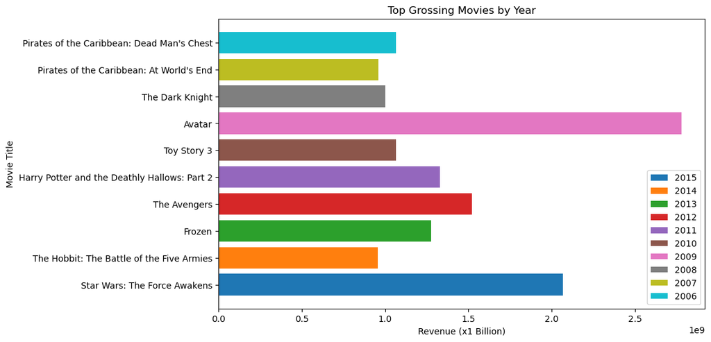

```python
# Plot bar chart: "Top Grossing Movies by Year"
plt.figure(figsize=(10, 6))
years = top_rev_movies['release_year']
for year in years:
    year_data = top_rev_movies[top_rev_movies['release_year'] == year]
    plt.barh(year_data['original_title'], year_data['revenue'], label=year)

plt.ylabel('Movie Title')
plt.xlabel('Revenue (x1 Billion)')
plt.title('Top Grossing Movies by Year')
plt.legend()
plt.show()
```

> From this chart, we can see that the three highest grossing movies, "Star Wars: The Force Awakens", "The Avengers", and "Avatar" were released in 2015, 2012, and 2009; respectively. This coincides with the outlier revenue data in the scatter plot, and the top revenue by release year. From this, it can be inferred that those movies played a significant role in overall revenue for each of those years.

> Another step can be taken to show in which quarter these top grossing movies fall.

```python
# Display the number of Top Grossing Movies by Quarter
top_qtr_cnt = top_rev_movies.groupby(['quarter'])['release_year'].count()
top_qtr_cnt
```

```
quarter
Q1    0
Q2    4
Q3    2
Q4    4
Name: release_year, dtype: int64
```

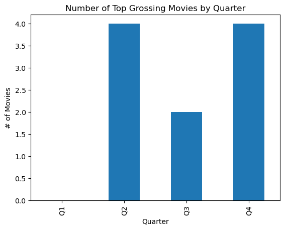

```python
top_qtr_cnt.plot(xlabel = 'Quarter', ylabel = '# of Movies', title ='Number of Top Grossing Movies by Quarter', kind='bar');
```

> It is shown here that Q1 held none of the top producing movies over the 10-year period with Q2 and Q4 tying at 4 and Q3 having 2. From this an assumption may be made that due to a lack of a blockbuster, Q1 does not bring in as much revenue on average as the other three quarters. Next, an analysis will be done to find out if one were to make that assumption, would it hold true.

### *Research Question 1:* Which quarter of the year typically brings in the least revenue?

> To answer this question, the release months will need to be grouped into yearly quarters. Once completed, average revenue can then be calculated and charted.

```python
# Add quarter column to the 10-year dataframe
add_quarter(ten_df)
ten_df.head()
```

|  | id | popularity | revenue | original_title | genres | release_date | release_year | quarter |
| --- | --- | --- | --- | --- | --- | --- | --- | --- |
| 0 | 135397 | 32.985763 | 1513528810 | Jurassic World | Action\|Adventure\|Science Fiction\|Thriller | 2015-06-09 | 2015 | Q2 |
| 1 | 76341 | 28.419936 | 378436354 | Mad Max: Fury Road | Action\|Adventure\|Science Fiction\|Thriller | 2015-05-13 | 2015 | Q2 |
| 2 | 262500 | 13.112507 | 295238201 | Insurgent | Adventure\|Science Fiction\|Thriller | 2015-03-18 | 2015 | Q1 |
| 3 | 140607 | 11.173104 | 2068178225 | Star Wars: The Force Awakens | Action\|Adventure\|Science Fiction\|Fantasy | 2015-12-15 | 2015 | Q4 |
| 4 | 168259 | 9.335014 | 1506249360 | Furious 7 | Action\|Crime\|Thriller | 2015-04-01 | 2015 | Q2 |

> With the new column created, the rows can now be cluster based on the quarter in which it was released to find how much revenue was generated on average during those periods.

```python
# Get the average quarterly revenue
qtr_rev_means(ten_df)
```

```
quarter
Q1    5.516271e+07
Q2    8.677324e+07
Q3    5.332449e+07
Q4    7.132752e+07
Name: revenue, dtype: float64
```

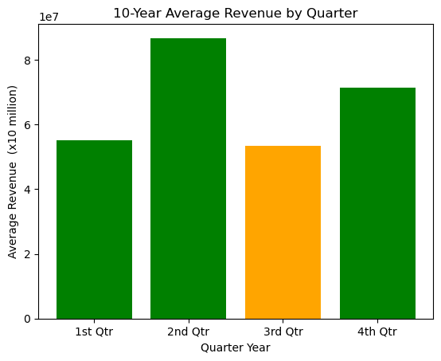

```python
# Plot bar chart: "10-Year Average Revenue by Quarter"
locations = [1, 2, 3, 4]
heights = qtr_rev_means(ten_df)

color = ['green', 'green', 'orange', 'green']

labels = ['1st Qtr', '2nd Qtr', '3rd Qtr', '4th Qtr']

plt.bar(locations, heights, tick_label=labels, color=color)
plt.title('10-Year Average Revenue by Quarter')
plt.xlabel('Quarter Year')
plt.ylabel('Average Revenue  (x10 million)');


plt.show()
```

### Answer 1:

#### On average, the 3rd quarter produced the least revenue during the 10-year period. Films during this time generated an average of ~ \$53M which is just shy of the 1st quarter at ~ $55M

### *Research Question 2:* Do more movie releases within a quarter equate to greater revenue?

> In order to answer this question, the total number of movies released for each quarter will need to be gathered and compared with the revenue.

```python
# Get total movies released per quarter
releases_count = ten_df.groupby(['quarter'])['original_title'].count()
releases_count
```

```
quarter
Q1    1278
Q2    1189
Q3    1630
Q4    1368
Name: original_title, dtype: int64
```

```python
# Get total revenue per quarter
total_rev = ten_df.groupby(['quarter'])['revenue'].sum()
total_rev
```

```
quarter
Q1     70497942946
Q2    103173383811
Q3     86918916163
Q4     97576042417
Name: revenue, dtype: int64
```

> Next, the number of releases and revenue for each quarter will be combined to better manage the data

```python
# Append the count and revenue data
bin_names = sorted(ten_df['quarter'].unique())
combo = np.column_stack((bin_names,releases_count, total_rev))
```

```python
# Create new dataframe from the combined arrays
rr_df = pd.DataFrame(combo, columns=['quarter', 'releases', 'total_revenue'])

rr_df.head()
```

|  | quarter | releases | total_revenue |
| --- | --- | --- | --- |
| 0 | Q1 | 1278 | 70497942946 |
| 1 | Q2 | 1189 | 103173383811 |
| 2 | Q3 | 1630 | 86918916163 |
| 3 | Q4 | 1368 | 97576042417 |

```python
rr_df.info()
```

```
<class 'pandas.core.frame.DataFrame'>
RangeIndex: 4 entries, 0 to 3
Data columns (total 3 columns):
 #   Column         Non-Null Count  Dtype
---  ------         --------------  -----
 0   quarter        4 non-null      object
 1   releases       4 non-null      object
 2   total_revenue  4 non-null      object
dtypes: object(3)
memory usage: 228.0+ bytes
```

> Since two arrays were joined, the data was read as objects (strings), so the datatypes for the `releases` and `total_revenue` columns need to be corrected.

```python
# Correct datatypes
dtype_convert(rr_df, 'total_revenue', 'float')
dtype_convert(rr_df, 'releases', 'int')
```

```
quarter           object
releases           int64
total_revenue    float64
dtype: object
```

> A pie chart will be used to compare each quarter of the total number of releases within the 10-year span.

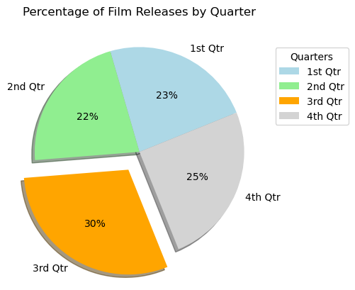

```python
# Plot pie chart: "Percentage of Film Releases by Quarter"
sizes = rr_df['releases']
explode = (0, 0, 0.2, 0)
c_color = ['lightblue', 'lightgreen', 'orange', 'lightgray']

fig, ax = plt.subplots()
ax.pie(sizes, explode=explode, autopct='%1.0f%%',labels =labels, colors=c_color,
       shadow=True, startangle=22)

plt.legend(labels,
          title="Quarters",
          loc="center left",
          bbox_to_anchor=(1, 0, 0.5, 1.5))

plt.title('Percentage of Film Releases by Quarter')

plt.show()
```

```python
# Display release in descending order
rel_sort = rr_df.sort_values(by=['releases'], ignore_index=True, ascending=False)
rel_sort.drop(['total_revenue'],axis=1)
```

|  | quarter | releases |
| --- | --- | --- |
| 0 | Q3 | 1630 |
| 1 | Q4 | 1368 |
| 2 | Q1 | 1278 |
| 3 | Q2 | 1189 |

> Now to explore the total revenue. Based upon the same time data, the gross revenue will be analyzed.

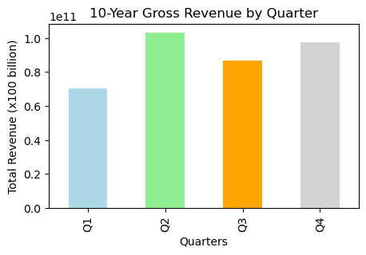

```python
# Plot bar chart: "10-Year Gross Revenue by Quarter"

rr_df.plot(x='quarter', y='total_revenue', kind='bar',
           legend=False, figsize=(5,3), color=c_color)

plt.title('10-Year Gross Revenue by Quarter')
plt.xlabel('Quarters')
plt.ylabel('Total Revenue (x100 billion)')

plt.show()
```

```python
# Display the the total revenue in descending order
rev_sort = rr_df.sort_values(by=['total_revenue'], ignore_index=True, ascending=False)
rev_sort.drop(['releases'],axis=1)
```

|  | quarter | total_revenue |
| --- | --- | --- |
| 0 | Q2 | 1.031734e+11 |
| 1 | Q4 | 9.757604e+10 |
| 2 | Q3 | 8.691892e+10 |
| 3 | Q1 | 7.049794e+10 |

> The data shows that, overall, movies released in the 2nd quarter ranks as number one and generated the most revenue totaling over \$100B. That is a stark contrast from the previous graph which showed that the least amount of films were released during that time.

### Answer 2

#### The data indicates that the overall quantity of movie releases do not determine revenue outcome within a quarter. The 2nd quarters had the least releases, but produces the greatest revenue. The 3rd quarters released the most movies, but only beat out one other quarter in terms of revenue.

## Conclusions

> Analyzing the data by quarter indicates that on average, within a 10-year period, revenue is not as high during the 3rd quarter of the year. The average revenue is shown as \$53M; $33M less than the topped ranked 2nd quarter which averages around \$86M.

> The data also suggests that the volume of releases does not necessarily equate to higher revenue. Although the 3rd quarter had the most movies released (roughly 1600), it failed to generate the most revenue. The data actually showed that the inverse occurred. The quarter with the lowest releases, the 2nd quarter, totaled over \$100B; the most of any quarter.

> What can be drawn from this is that the quarter in which a movie is released is not the only factor that determines the outcome of greater revenue. This can also be said about the number of releases within a quarter as most of the quarters ranked differently in each analysis. There could be many other factors that could effecting a movie's success such as marketing, popularity, content interest, etc. that were not available or not explored in this report.

### Cite

McKinney, W., & others. (2010). Data structures for statistical computing in python. In Proceedings of the 9th Python in Science Conference (Vol. 445, pp. 51–56).

Harris, C.R., Millman, K.J., van der Walt, S.J. et al. Array programming with NumPy. Nature 585, 357–362 (2020). DOI: 10.1038/s41586-020-2649-2. (Publisher link).

### Thanks for viewing

S.J. Richardson

sqljamz.github.io